# Project ~ Applied Stats

## Applied Stats Project

### 1. Import Libs

```python
import ast, platform
import seaborn as sns
import matplotlib.pyplot as plt
import plotly.express as px
import numpy as np, pandas as pd
import statsmodels.api as sm
from statsmodels.formula.api import ols
from scipy.stats import ttest_ind, ttest_1samp, levene
from statsmodels.stats.proportion import proportions_ztest
%matplotlib inline
print(f"Py: {platform.python_version()}")
```

```
Py: 3.8.5
```

### 2. Read the dataset

```python
df = pd.read_csv('insurance.csv') # read in the data into a dataframe
df.head(15)
```

|  | age | sex | bmi | children | smoker | region | charges |
| --- | --- | --- | --- | --- | --- | --- | --- |
| 0 | 19 | female | 27.900 | 0 | yes | southwest | 16884.92400 |
| 1 | 18 | male | 33.770 | 1 | no | southeast | 1725.55230 |
| 2 | 28 | male | 33.000 | 3 | no | southeast | 4449.46200 |
| 3 | 33 | male | 22.705 | 0 | no | northwest | 21984.47061 |
| 4 | 32 | male | 28.880 | 0 | no | northwest | 3866.85520 |
| 5 | 31 | female | 25.740 | 0 | no | southeast | 3756.62160 |
| 6 | 46 | female | 33.440 | 1 | no | southeast | 8240.58960 |
| 7 | 37 | female | 27.740 | 3 | no | northwest | 7281.50560 |
| 8 | 37 | male | 29.830 | 2 | no | northeast | 6406.41070 |
| 9 | 60 | female | 25.840 | 0 | no | northwest | 28923.13692 |
| 10 | 25 | male | 26.220 | 0 | no | northeast | 2721.32080 |
| 11 | 62 | female | 26.290 | 0 | yes | southeast | 27808.72510 |
| 12 | 23 | male | 34.400 | 0 | no | southwest | 1826.84300 |
| 13 | 56 | female | 39.820 | 0 | no | southeast | 11090.71780 |
| 14 | 27 | male | 42.130 | 0 | yes | southeast | 39611.75770 |

### 3. Premilinary data statistics

```python
df.shape # 3.a. shape (rows, columns) = (datapoints, variables)
```

```
(1338, 7)
```

> **1338** different data points for insurance information along **7** dimensions/variables

```python
df.dtypes # 3.b. data types of attributes
```

```
age           int64
sex          object
bmi         float64
children      int64
smoker       object
region       object
charges     float64
dtype: object
```

> **age, bmi, charges** are numeric attributes and **children, sex, smoker, region** are all categorical attributes.  
> Also, there's no implicit ordering among the different categories in the sex, region, smoker cateogorical attributes, i.e, nominal attributes

```python
df.isna().sum() # 3.c. No missing values, can proceed to data exploration and analysis without imputation or dropping data.
```

```
age         0
sex         0
bmi         0
children    0
smoker      0
region      0
charges     0
dtype: int64
```

```
As a standard summary for general use, the 5-number summary provides about the right amount of detail.

— Page 37, Understanding Robust and Exploratory Data Analysis, 2000.
```

```python
df.describe() # 3.d. 5 Point summary of numeric variables: age, bmi, children, charges
```

|  | age | bmi | children | charges |
| --- | --- | --- | --- | --- |
| count | 1338.000000 | 1338.000000 | 1338.000000 | 1338.000000 |
| mean | 39.207025 | 30.663397 | 1.094918 | 13270.422265 |
| std | 14.049960 | 6.098187 | 1.205493 | 12110.011237 |
| min | 18.000000 | 15.960000 | 0.000000 | 1121.873900 |
| 25% | 27.000000 | 26.296250 | 0.000000 | 4740.287150 |
| 50% | 39.000000 | 30.400000 | 1.000000 | 9382.033000 |
| 75% | 51.000000 | 34.693750 | 2.000000 | 16639.912515 |
| max | 64.000000 | 53.130000 | 5.000000 | 63770.428010 |

```
The five-number summary involves the calculation of 5 summary statistical quantities: namely:

Median: The middle value in the sample, also called the 50th percentile or the 2nd quartile. | 50%
1st Quartile: The 25th percentile.                                                           | 25%
3rd Quartile: The 75th percentile.                                                           | 75%
Minimum: The smallest observation in the sample.                                             | min
Maximum: The largest observation in the sample.                                              | max
— Machine Learning Mastery
```

#### 3.e. Distribution of bmi, age, and, charges

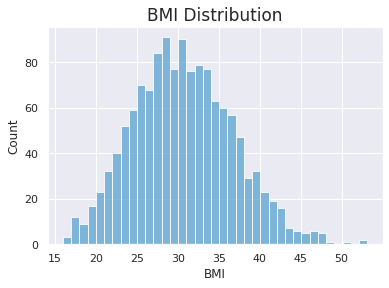

```python
sns.set()
sns.histplot(df.bmi, kde = False, bins = 37, color = '#5aa2ce')
plt.xlabel("BMI")
plt.title("BMI Distribution", fontsize = 17)
plt.show()
```

> BMI Seems to be normally distributed with a mean of 30.66 and standard deviation of 6.09

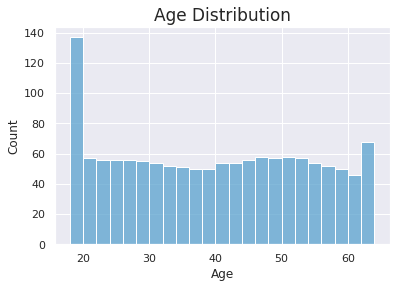

```python
sns.set()
sns.histplot(df.age, kde = False, bins = 23, color = '#5aa2ce')
plt.xlabel("Age")
plt.title("Age Distribution", fontsize = 17)
plt.show()
```

> Distribution of Age seems to peak at 20s with somewhat uniform counts from 20 to 60.  
> This implies that that there are relatively many more people in their twenties in our insurance information dataset.

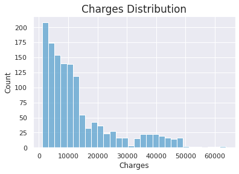

```python
sns.set()
sns.histplot(df.charges, kde = False, bins = 'auto', color = '#5aa2ce')
plt.xlabel("Charges")
plt.title("Charges Distribution", fontsize = 17)
plt.show()
```

> Charges distribution is skewed to the right (tail is on the right), and seems to follow a pareto distribution.  
> We can infer that most charges are less than 15000 and lesser number of datapoints where charges were higher.

```python
df[['age', 'bmi', 'charges']].skew(axis = 0) # 3.f. Measure of Skew
```

```
age        0.055673
bmi        0.284047
charges    1.515880
dtype: float64
```

> Charges has much higher value of skew as expected from seeing the distributions

> Skewness is a measure of symmetry in a distribution. Actually, it’s more correct to describe it as a measure of lack of symmetry.  
> It's a measure of asymmetry of the probability distribution of a real-valued random variable about its mean.  
> A standard normal distribution is perfectly symmetrical and has zero skew.  
> Pandas dataframe.skew() function return unbiased skew over requested axis Normalized by N-1.

#### 3.g. Checking for outliers in age, bmi, and, charges

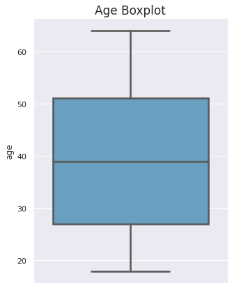

```python
sns.set()
plt.figure(figsize = [5, 7])
sns.boxplot(y = df.age, linewidth = 2.60, color = '#5aa2ce')
plt.title("Age Boxplot", fontsize = 17)
plt.show()
```

```python
# Outliers lie beyond the whiskers in the boxplot, No outliers in the age column
```

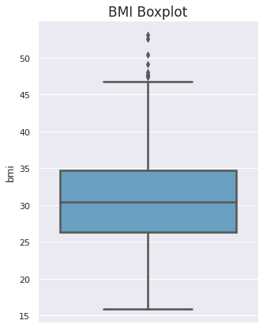

```python
sns.set()
plt.figure(figsize = [5, 7])
sns.boxplot(y = df.bmi, linewidth = 2.60, color = '#5aa2ce')
plt.title("BMI Boxplot", fontsize = 17)
plt.show()
```

[figure not shown]

```python
plt.figure(figsize = [5, 7])
sns.boxplot(y = df.charges, linewidth = 2.60, color = '#5aa2ce')
plt.title("BMI Boxplot", fontsize = 17)
plt.show()
```

```python
Q1 = df[['bmi']].quantile(0.25)
Q3 = df[['bmi']].quantile(0.75)
IQR = Q3 - Q1
IQR
```

```
bmi    8.3975
dtype: float64
```

```python
df[((df < (Q1 - 1.5 * IQR)) |(df > (Q3 + 1.5 * IQR))).any(axis=1)].sort_values(['bmi'], ascending = [True])
```

|  | age | sex | bmi | children | smoker | region | charges |
| --- | --- | --- | --- | --- | --- | --- | --- |
| 543 | 54 | female | 47.41 | 0 | yes | southeast | 63770.42801 |
| 401 | 47 | male | 47.52 | 1 | no | southeast | 8083.91980 |
| 860 | 37 | female | 47.60 | 2 | yes | southwest | 46113.51100 |
| 1088 | 52 | male | 47.74 | 1 | no | southeast | 9748.91060 |
| 286 | 46 | female | 48.07 | 2 | no | northeast | 9432.92530 |
| 116 | 58 | male | 49.06 | 0 | no | southeast | 11381.32540 |
| 847 | 23 | male | 50.38 | 1 | no | southeast | 2438.05520 |
| 1047 | 22 | male | 52.58 | 1 | yes | southeast | 44501.39820 |
| 1317 | 18 | male | 53.13 | 0 | no | southeast | 1163.46270 |

> 9 Outliers in the bmi cateogory with bmi raning from 47.41 to 53.13

```python
Q1 = df[['charges']].quantile(0.25)
Q3 = df[['charges']].quantile(0.75)
IQR = Q3 - Q1
IQR
```

```
charges    11899.625365
dtype: float64
```

```python
df[((df < (Q1 - 1.5 * IQR)) |(df > (Q3 + 1.5 * IQR))).any(axis=1)].sort_values(['charges'], ascending = [True])
```

|  | age | sex | bmi | children | smoker | region | charges |
| --- | --- | --- | --- | --- | --- | --- | --- |
| 623 | 18 | male | 33.535 | 0 | yes | northeast | 34617.84065 |
| 1078 | 28 | male | 31.680 | 0 | yes | southeast | 34672.14720 |
| 223 | 19 | male | 34.800 | 0 | yes | southwest | 34779.61500 |
| 689 | 27 | male | 31.130 | 1 | yes | southeast | 34806.46770 |
| 1291 | 19 | male | 34.900 | 0 | yes | southwest | 34828.65400 |
| ... | ... | ... | ... | ... | ... | ... | ... |
| 819 | 33 | female | 35.530 | 0 | yes | northwest | 55135.40209 |
| 577 | 31 | female | 38.095 | 1 | yes | northeast | 58571.07448 |
| 1230 | 52 | male | 34.485 | 3 | yes | northwest | 60021.39897 |
| 1300 | 45 | male | 30.360 | 0 | yes | southeast | 62592.87309 |
| 543 | 54 | female | 47.410 | 0 | yes | southeast | 63770.42801 |

139 rows × 7 columns

> 139 Outliers in Charges with charges upwards of 34,600 bucks to 63,770

#### 3.h. Univariate Distribution of Categorical Variables

```python
df.sex.value_counts()
```

```
male      676
female    662
Name: sex, dtype: int64
```

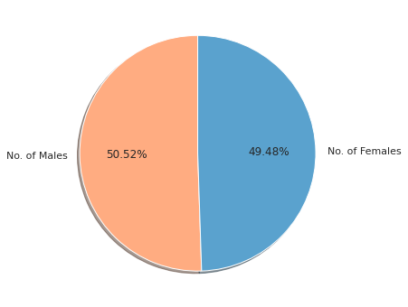

```python
# Distribution of genders in the dataset

males = len(df[df['sex'] == 'male'])
females = len(df[df['sex'] == 'female'])
plt.pie(x=[males, females], explode=(0, 0), labels=['No. of Males', 'No. of Females'], autopct='%1.2f%%', \
        shadow=True, startangle=90,colors = ['#ffac81','#5aa2ce'])
fig = plt.gcf()
fig.set_size_inches(6,6)
plt.show()
```

> Fairly balance dataset in terms of gender with 50.52% males and 49.48% females

```python
df.smoker.value_counts()
```

```
no     1064
yes     274
Name: smoker, dtype: int64
```

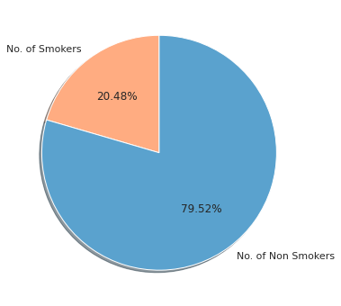

```python
# Distribution of smokers in the dataset

smokers = len(df[df['smoker'] == 'yes'])
non_smokers = len(df[df['smoker'] == 'no'])
plt.pie(x=[smokers, non_smokers], explode=(0, 0), labels=['No. of Smokers', 'No. of Non Smokers'], autopct='%1.2f%%', \
        shadow=True, startangle=90,colors = ['#ffac81','#5aa2ce'])
fig = plt.gcf()
fig.set_size_inches(6,6)
plt.show()
```

> There are many more non smokers than smokers in the dataset.

```python
df.children.value_counts()
```

```
0    574
1    324
2    240
3    157
4     25
5     18
Name: children, dtype: int64
```

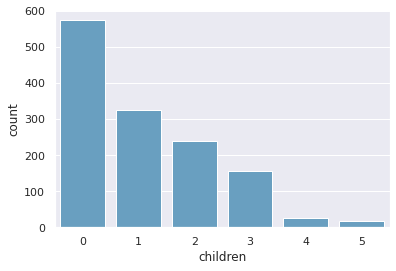

```python
sns.countplot(x = df.children, color ='#5aa2ce')
plt.show()
```

> The Frequency of Number of children is decreasing as the no. of children increase (right skew)

```python
df.region.value_counts()
```

```
southeast    364
southwest    325
northwest    325
northeast    324
Name: region, dtype: int64
```

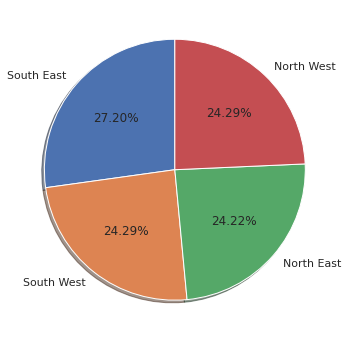

```python
# Distribution of regions in the dataset

se = len(df[df['region'] == 'southeast'])
sw = len(df[df['region'] == 'southwest'])
ne = len(df[df['region'] == 'northeast'])
nw = len(df[df['region'] == 'northwest'])

plt.pie(x=[se, sw, ne, nw], explode=(0, 0, 0 ,0), labels=['South East', 'South West', 'North East', 'North West'], autopct='%1.2f%%', \
        shadow=True, startangle=90)
fig = plt.gcf()
fig.set_size_inches(6,6)
plt.show()
```

> Almost Equivalent proportions of patients across various regions are present in the dataset.

#### 3.i. Pair Plot

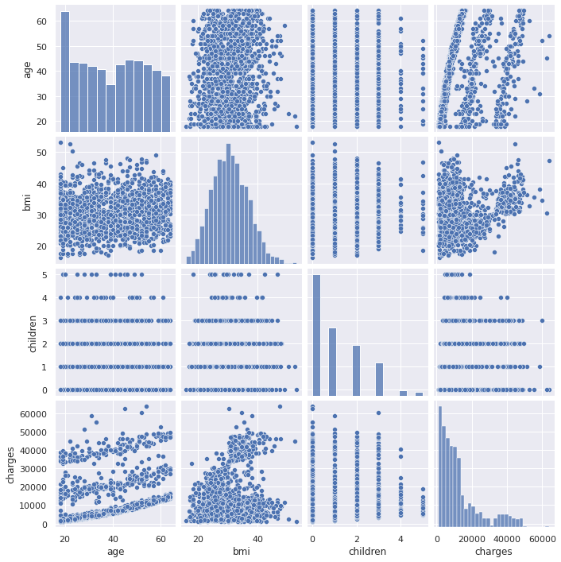

```python
sns.pairplot(df, palette = '#5aa2ce')
plt.show()
```

#### Heatmap

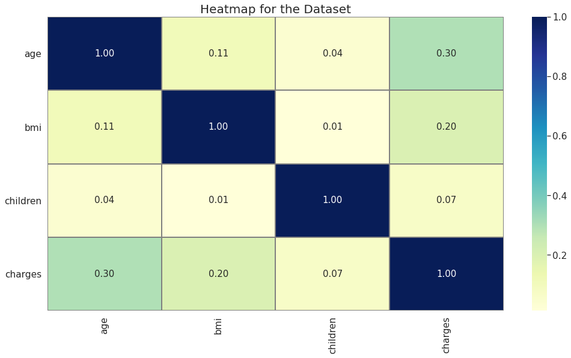

```python
plt.rcParams['figure.figsize'] = (17, 9)
plt.style.use('ggplot')
sns.set(font_scale=1.4)
sns.heatmap(df.corr(), annot = True, annot_kws={"size": 15}, fmt='.2f', cmap = 'YlGnBu', linewidths=1, linecolor='gray')
plt.title('Heatmap for the Dataset', fontsize = 20, fontweight=30)
plt.yticks(rotation=0)
plt.xticks(rotation=90)
plt.show()
```

> All of the numerical variables have pearson correlationless than 0.3. Not very highly correlated. So, we need not worry about confounding variables or dropping highly correlated variables.

### 4. Hypothesis Testing

### 4.a. Do charges of people who smoke differ significantly from the people who don't?

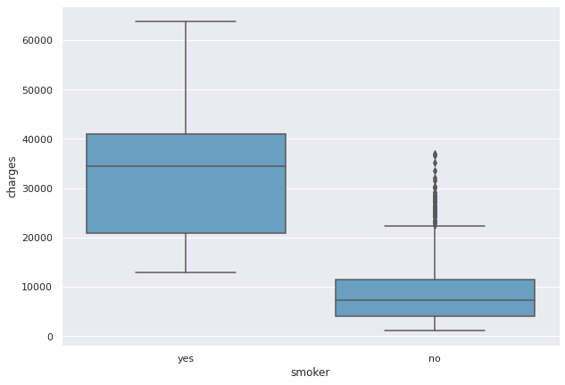

```python
sns.set()
plt.figure(figsize = [10, 7])
sns.boxplot(data = df, y = 'charges', x = 'smoker', color = '#5aa2ce')
plt.show()
```

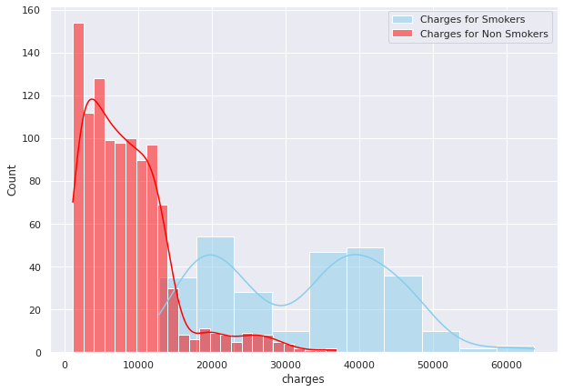

```python
sns.set()
plt.figure(figsize = [10, 7])
sns.histplot(df[df.smoker == 'yes']["charges"] , color="skyblue", label="Charges for Smokers", kde = True)
sns.histplot(df[df.smoker == 'no']["charges"] , color="red", label="Charges for Non Smokers", kde = True)
plt.legend()
plt.show()
```

> Visually, we can infer that the premium charges are definitely higher for smokers than non-smokers  
> We should conduct a hypothesis test (t-test) for the differences in means across the two smokers and non-smoker charges to test.

> $H 0 : μ s = μ ns$  
> $H a : μ s ≠ μ ns$

```python
charges_smokers = df[df.smoker == 'yes']['charges']
charges_non_smokers = df[df.smoker == 'no']['charges']
```

```python
charges_smokers.mean()
```

```
32050.23183153285
```

```python
charges_non_smokers.mean()
```

```
8434.268297856199
```

```python
t_stat, p_value = ttest_ind(charges_smokers, charges_non_smokers)
print(f'T Statistic: {t_stat} | P Value: {p_value}')
```

```
T Statistic: 46.664921172723716 | P Value: 8.271435842177219e-283
```

> The P Value for the ttest is 8.271e-283 which is far less than a level of signifance of: 0.05. (p-value is the observed probability of the null hypothesis to happen) So, we can reject the null hypothesis that the charges both smokers and non smokers have equal means. The charges do signifcantly differ.

### 4.b. Does bmi of males differ significantly from that of females?

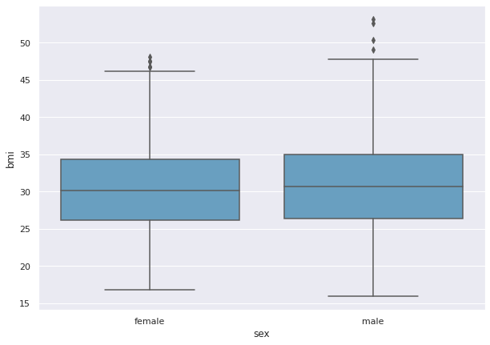

```python
sns.set()
plt.figure(figsize = [10, 7])
sns.boxplot(data = df, y = 'bmi', x = 'sex', color = '#5aa2ce')
plt.show()
```

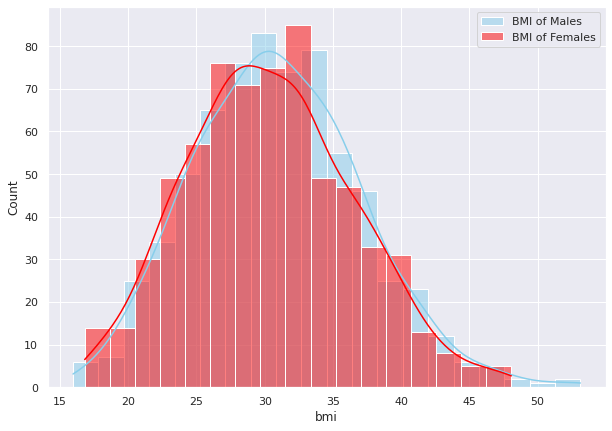

```python
sns.set()
plt.figure(figsize = [10, 7])
sns.histplot(df[df.sex == 'male']["bmi"] , color="skyblue", label="BMI of Males", kde = True)
sns.histplot(df[df.sex == 'female']["bmi"] , color="red", label="BMI of Females", kde = True)
plt.legend()
plt.show()
```

```python
bmi_males = df[df.sex == 'male']['bmi']
bmi_females = df[df.sex == 'female']['bmi']
```

```python
bmi_males.mean()
```

```
30.943128698224832
```

```python
bmi_females.mean()
```

```
30.377749244713023
```

```python
t_stat, p_value = ttest_ind(bmi_males, bmi_females)
print(f'T Statistic: {t_stat} | P Value: {p_value}')
```

```
T Statistic: 1.696752635752224 | P Value: 0.08997637178984932
```

> The P Value for the two samples t test for bmi across males and females is 0.0899 which is greater than 0.05. So,we fail to reject the null hypothesis that the two samples have equal means. Hence, The BMI of males and females do not differ significantly.

### 4.c. Is the proportion of smokers significantly different in different genders?

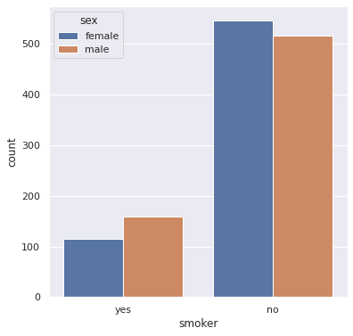

```python
sns.set()
plt.figure(figsize = [6, 6])
sns.countplot(data = df, x = 'smoker', hue = 'sex' )
plt.show()
```

```python
female_smokers = df[df['sex'] == 'female'].smoker.value_counts()[1]  # number of female smokers
male_smokers = df[df['sex'] == 'male'].smoker.value_counts()[1] # number of male smokers
n_females = df.sex.value_counts()[1] # number of females in the data
n_males = df.sex.value_counts()[0] #number of males in the data
```

```python
print([female_smokers, male_smokers] , [n_females, n_males])
print(f' Proportion of smokers in females, males = {round(115/662,2)}%, {round(159/676,2)}% respectively')
```

[output not shown]

```python
stat, p_value = proportions_ztest([female_smokers, male_smokers] , [n_females, n_males])
print(f'Z Statistic: {t_stat} | P Value: {p_value}')
```

[output not shown]

> P Value is 0.005 which is less than 0.05; Hence, we reject the null hypothesis that the proportions are equal. So, the proportions of smokers across both genders differ significantly.

### 4.d. Is the distribution of bmi across women with no children, one child and two children, the same?

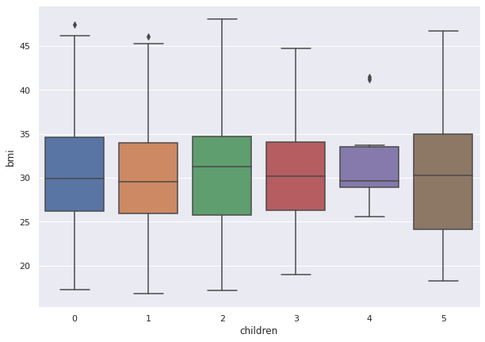

```python
female_df = df[df.sex == 'female']
sns.set()
plt.figure(figsize = [10, 7])
sns.boxplot(data = female_df, y = 'bmi', x = 'children')
plt.show()
```

```python
bmi_zero_children = female_df[female_df.children == 0]['bmi']
bmi_one_child = female_df[female_df.children == 1]['bmi']
bmi_two_children = female_df[female_df.children == 2]['bmi']
```

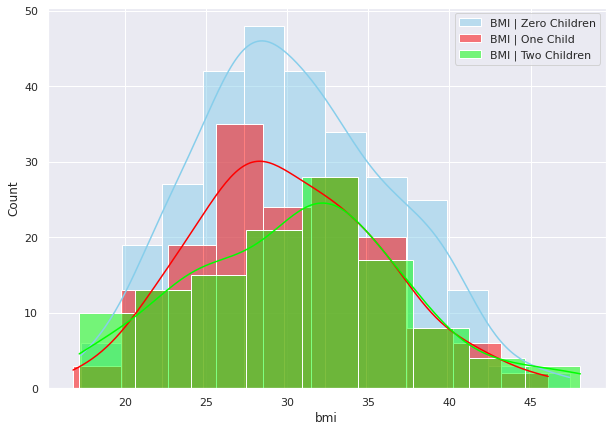

```python
sns.set()
plt.figure(figsize = [10, 7])
sns.histplot(bmi_zero_children, color="skyblue", label="BMI | Zero Children", kde = True)
sns.histplot(bmi_one_child, color="red", label="BMI | One Child", kde = True)
sns.histplot(bmi_two_children, color="lime", label="BMI | Two Children", kde = True)
plt.legend()
plt.show()
```

> Testing multiple sample means using ANOVA

```python
df_three = df[df.children <= 2]
```

```python
mod = ols('bmi ~ children', data = df_three).fit()
sm.stats.anova_lm(mod, typ=2)
```

|  | sum_sq | df | F | PR(>F) |
| --- | --- | --- | --- | --- |
| children | 27.272296 | 1.0 | 0.719586 | 0.396458 |
| Residual | 43054.351120 | 1136.0 | NaN | NaN |